# Code-level analyses

11/15/2017

# Wood traits as a predictor

## *Hyp (code-level)* Variation in wood traits will lead to differences in decay model fit (r2), rate (k), and lagginess (alpha). Specifically, we expect samples with (a) high waterperc, (b) low density and C, (c) high P, K, Ca, Mn, Fe, Zn, and N, and (d) thicker bark (potential mech: limiting microbial colonization) to have better-fiting decay models (r2), faster decay rates (k), and less lagginess (alpha).

### r2

**greater water content and greater Zn and N leads to better-fitting decay models**

Note: This result changed when I changed waterperc to g water/g wet weight. When waterperc was in terms of g/g dry weight, the best model that greater water content and less C leads to better-fitting decay models

```
##
## Call:
## lm(formula = ne.r2 ~ waterperc + barkthick + Ca + Zn + N + C,
##     data = spdf.traits)
##
## Residuals:
##      Min       1Q   Median       3Q      Max
## -0.11753 -0.02941  0.00184  0.02233  0.12797
##
## Coefficients:
##               Estimate Std. Error t value Pr(>|t|)
## (Intercept)  1.278e+00  6.457e-01   1.979   0.0590 .
## waterperc    7.405e-03  1.509e-03   4.906 4.75e-05 ***
## barkthick   -3.098e-02  1.587e-02  -1.953   0.0622 .
## Ca          -1.189e-05  6.783e-06  -1.753   0.0919 .
## Zn           1.504e-03  5.664e-04   2.654   0.0136 *
## N            2.092e-01  8.436e-02   2.480   0.0202 *
## C           -1.698e-02  1.291e-02  -1.315   0.2006
## ---
## Signif. codes:  0 '***' 0.001 '**' 0.01 '*' 0.05 '.' 0.1 ' ' 1
##
## Residual standard error: 0.06306 on 25 degrees of freedom
## Multiple R-squared:  0.559,  Adjusted R-squared:  0.4532
## F-statistic: 5.282 on 6 and 25 DF,  p-value: 0.001234
```

### k

**small size stems, greater water content, thinner bark, less Ca, more Zn, and more N lead to faster decay**

NOTE from Will: Density explains the same part of the variation in decay rates that initial water content does, only less well. (In other words, although, density gets dropped from the best model by the model selection procedure, if we remove initial water from consideration entirely, density is included in the model as the best predictor.)

So my current interpretation is that wood water rentention–related to fiber saturation point and partially captured by the density measurement–has a strong effect on long-term decomposition rates, possibly by maintaining fungal activity further into dry periods. There is also a very likely interaction between this water retention capacity with the fungal community (see results in Setting the Stage paper, Lee et al. in review).

```
##
## Call:
## lm(formula = k ~ size + waterperc + barkthick + Ca + Zn + N +
##     C, data = spdf.traits)
##
## Residuals:
##       Min        1Q    Median        3Q       Max
## -0.092617 -0.034671  0.007271  0.029023  0.123640
##
## Coefficients:
##               Estimate Std. Error t value Pr(>|t|)
## (Intercept)  6.021e-01  5.754e-01   1.046 0.305851
## sizesmall    9.050e-02  2.405e-02   3.763 0.000958 ***
## waterperc    8.990e-03  1.378e-03   6.524 9.53e-07 ***
## barkthick   -3.862e-02  1.406e-02  -2.748 0.011198 *
## Ca          -1.869e-05  5.920e-06  -3.157 0.004263 **
## Zn           1.811e-03  4.922e-04   3.680 0.001177 **
## N            2.334e-01  7.674e-02   3.041 0.005628 **
## C           -1.475e-02  1.135e-02  -1.300 0.206001
## ---
## Signif. codes:  0 '***' 0.001 '**' 0.01 '*' 0.05 '.' 0.1 ' ' 1
##
## Residual standard error: 0.05446 on 24 degrees of freedom
## Multiple R-squared:  0.7486, Adjusted R-squared:  0.6752
## F-statistic: 10.21 on 7 and 24 DF,  p-value: 6.942e-06
```

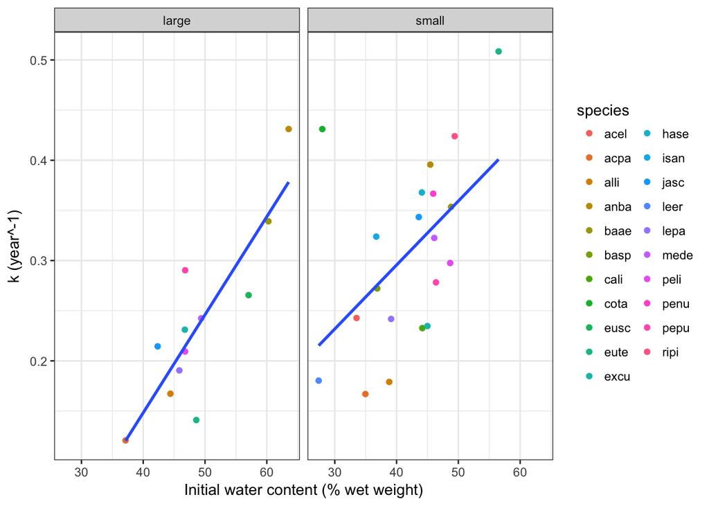

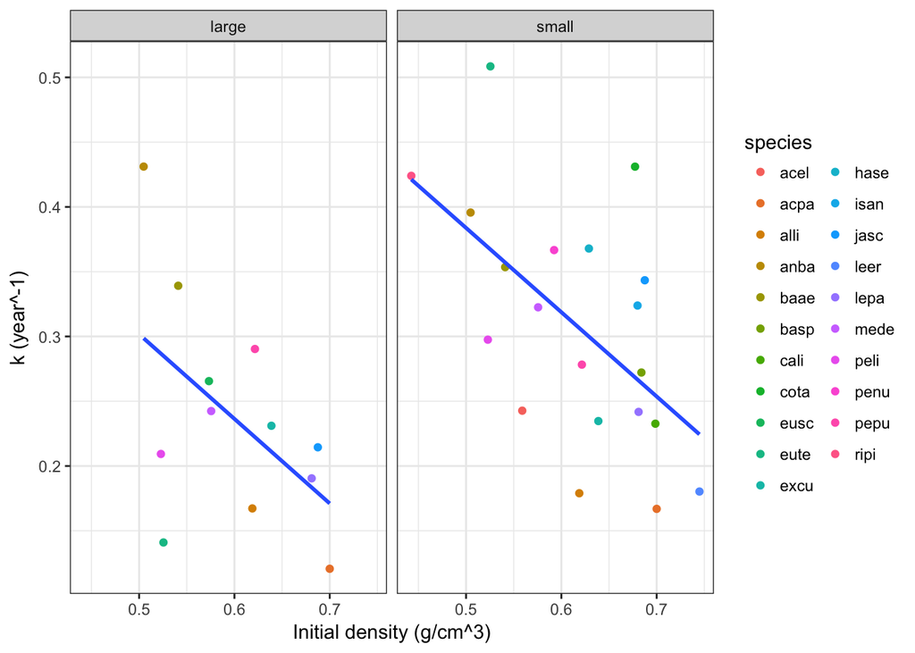

### t70

Note: This result changed when I changed waterperc to g water/g wet weight. When waterperc was in terms of g/g dry weight, the best model indicated that large size stems, less water content, more Ca, and less Zn lead to longer wood “70%”-lives

```
##
## Call:
## lm(formula = t70 ~ size + waterperc + barkthick + Ca + Zn + N,
##     data = spdf.traits)
##
## Residuals:
##      Min       1Q   Median       3Q      Max
## -0.55548 -0.15857 -0.00642  0.07054  0.58357
##
## Coefficients:
##               Estimate Std. Error t value Pr(>|t|)
## (Intercept)  3.799e+00  4.125e-01   9.209 1.65e-09 ***
## sizesmall   -6.284e-01  1.314e-01  -4.783 6.54e-05 ***
## waterperc   -4.956e-02  7.653e-03  -6.476 8.79e-07 ***
## barkthick    1.752e-01  7.308e-02   2.397 0.024301 *
## Ca           1.234e-04  3.203e-05   3.851 0.000725 ***
## Zn          -9.272e-03  2.698e-03  -3.436 0.002070 **
## N           -9.985e-01  4.258e-01  -2.345 0.027272 *
## ---
## Signif. codes:  0 '***' 0.001 '**' 0.01 '*' 0.05 '.' 0.1 ' ' 1
##
## Residual standard error: 0.3026 on 25 degrees of freedom
## Multiple R-squared:  0.735,  Adjusted R-squared:  0.6714
## F-statistic: 11.56 on 6 and 25 DF,  p-value: 3.442e-06
```

### alpha— don’t interpret yet

# Community as a predictor

### First, filter community matrix to include only taxa that are present in a least 20% of all the samples. This step removes taxa that may not contribute much to our understanding of the relationship between species’ multivariate abundance and environment.

```
## [1] "Keep 150 of 6128 OTUs"
```

## *Hyp (code-level)* Average initial microbial communitiy compositions will predict variation in decay model fit (r2), rate (k), and lagginess (alpha).

### r2, k, t70, (alpha)

**none of the community components are significant predictors**

# Community+traits as a predictor

## *Hyp (code-level)* After accounting for variation in decay due to wood traits, average initial microbial communitiy compositions will predict variation in decay model fit (r2), rate (k), and lagginess (alpha).

### r2, k, t70, (alpha)

**none of the community components are significant predictors**

# Diversity (and diversity of specific clades) as a predictor

**Note that the full community matrix was used for these analyses** ## *Hyp-a (code-level)* Greater microbial diversity (richness, Shannon diversity, … add phylogenetic diversity) will lead to better-fitting decay models (ne.r2), faster decay (k), and less lagginess (alpha) because of the selection effect for fast decayers and complementarity among taxa for decay.  
Hyp-Alt: Greater microbial diversity will lead to worse-fitting decay models (ne.r2), slower decay (k), and more lagginess (alpha) because taxa will be allocating more of their resources to combat one another.

### Richness, Shannon’s H

**No pattern**

## *Hyp-b (code-level)* Greater saprotroph and basidiomycete richness will lead to better-fitting decay models (ne.r2), faster decay (k), and less lagginess (alpha) because the community does not need to wait for the arrival of key decayers to act on the wood substrate.

Hyp-Alt: Greater saprotroph and basidiomycete richness will lead to worse-fitting decay models (ne.r2), slower decay (k), and more lagginess (alpha) because decayers will be allocating more of their resources to combat one another.

### Saprotroph richness, Basidio richness

**No pattern**

## *Hyp-c (code-level)* Greater pathogen and oomycete richness will lead to worse-fitting decay models (ne.r2), slower decay (k), and more lagginess (alpha) because the presence of these organisms will inhibit the establishment and activity of decayers.

### Pathogen richness, oomycete richness

**No pattern**

# Diversity plus traits as a predictor

## *Hyp (code-level)* After accounting for variation in decay due to wood traits, average initial microbial diversity (richness, Shannon diversity, … add phylogenetic diversity) will predict variation in decay model fit (r2), rate (k), and lagginess (alpha).

### Richness, Shannon’s H, Saprotroph richness, Basidio richness, Pathogen richness, Oomycete richness

**No pattern**

# Relationship between wood traits and community

## *Hyp (code-level)* Average initial microbial communitiy compositions will covary with initial wood traits